# Transitions Bibliometrics 2019

Daniel S. Hain

06 February, 2019

# 1 Initial Corpus generation & inspection

## 1.1 Corpus Creation

### 1.1.1 General steps

1. Scopus download of documents retrieved from search string from Markard et al. (2012), resulting in ca 2.800 documents. Limited to LANGUAGE=ENGLISH and TYPE=ARTICLE OR CONFERENCE PAPER OR BOOK OR BOOKCHAPTER OR EDITORIAL.
2. Selecting “seed” publications. 1% most cited total + 1% most cited per year + top3 cited papers from each 2015-2017. Ex-post manual insertion and exclusion (authority based)
3. Retrieving for each seed 500 publications with most shared references. Again limited to LANGUAGE=ENGLISH and TYPE=ARTICLE OR CONFERENCE PAPER OR BOOK OR BOOKCHAPTER OR EDITORIAL.
4. Adittional ex. post filtering based on citations recieved and connectivity in bibliographic coupling network (see below)

### 1.1.2 Final corpus Size

```
## Number of unique publications in the final corpus:  6184
```

Generally, 33 x 500 = 16.500 documents downloaded. However, due to an overlap of publications with most shared references to seed papers, final corpus is smaller. Further, number of adittional references per seed added decline. Yet, increase in non-overlapping references indicates the corpus is not saturated yet.

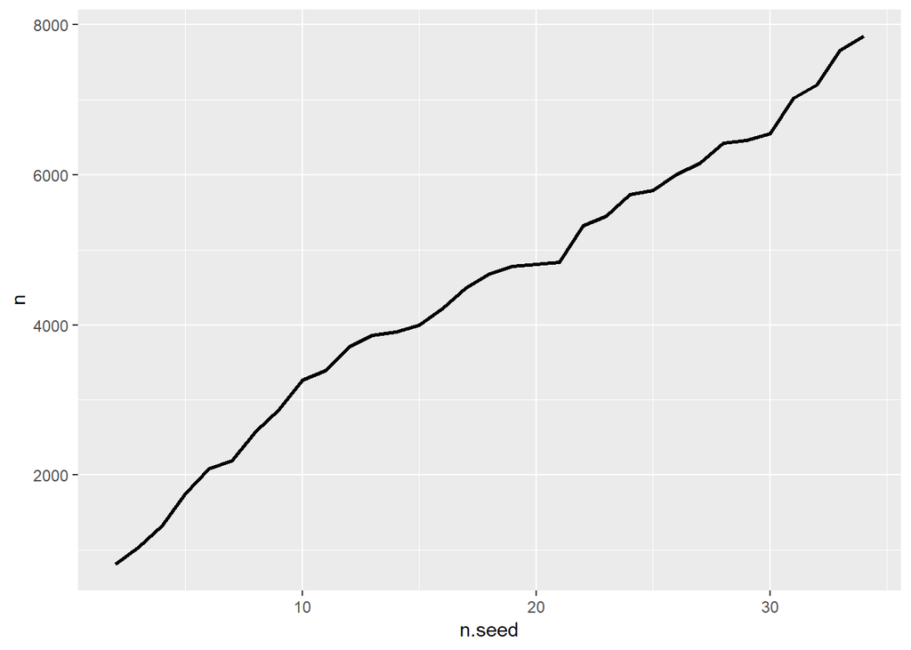

### 1.1.3 Seed Paper

[output not shown]

## 1.2 Publications

Note: The following tables refer to the documents in the main corpus.

### 1.2.1 Top appearing authors, journals, institutions, countries, keywords

Generally, `dgr` refers to the degree, `n` to the number of publications. Subscript `.f` indicates the number is fractionalized (divided by the number of elements per publication)

| Authors AU | Authors n.f | Journals JI | Journals n | Institutions C | Institutions n.f | countries C_CN | countries n.f | Keywords DE | Keywords n |
| --- | --- | --- | --- | --- | --- | --- | --- | --- | --- |
| Geels F | 33 | Res Policy | 257 | University of Sussex | 103 | United Kingdom | 1084 | innovation | 347 |
| Nelson R | 19 | Energy Policy | 226 | Delft University of Technology | 87 | United States | 967 | sustainability | 249 |
| Smith A | 17 | Technol. Forecast. Soc. Change | 194 | Lunds Universitet | 82 | Netherlands | 760 | climate change | 203 |
| Bulkeley H | 16 | J. Clean. Prod. | 171 | Wageningen University and Research Centre | 79 | Sweden | 422 | governance | 160 |
| Hekkert M | 14 | Ecol. Soc. | 161 | Technische Universiteit Eindhoven | 73 | Germany | 362 | transition | 109 |
| Foxon T | 14 | Environmental Innovation and Societal Transitions | 119 | Utrecht University | 71 | Australia | 254 | transition management | 107 |
| Carlsson B | 14 | Technol. Anal. Strateg. Manage. | 113 | Erasmus University Rotterdam | 70 | Italy | 232 | sustainable development | 104 |
| Malerba F | 13 | Procedia CIRP | 109 | University of Manchester | 65 | Canada | 207 | resilience | 102 |
| Raven R | 13 | Sustainability | 105 | Linköpings universitet | 59 | France | 166 | transitions | 89 |
| Kemp R | 13 | Global Environ. Change | 90 | Chalmers University of Technology | 57 | Denmark | 159 | learning | 88 |
| Jacobsson S | 13 | Ind. Corp. Change | 87 | University of East Anglia | 46 | Norway | 129 | renewable energy | 88 |
| Shove E | 12 | Energy Res. Soc. Sci. | 68 | Aalborg Universitet | 45 | Spain | 111 | innovation policy | 82 |
| Berkes F | 10 | Eur. Plann. Stud. | 67 | Vrije Universiteit Amsterdam | 42 | Finland | 110 | sustainability transitions | 79 |
| Leydesdorff L | 10 | Technovation | 66 | Cardiff University | 41 | Austria | 105 | strategic niche management | 72 |
| Loorbach D | 10 | Clim. Change | 63 | UCL | 41 | Japan | 100 | product-service systems | 69 |
| Brown R | 10 | J. Evol. Econ. | 52 | University of Cambridge | 40 | Switzerland | 98 | technological change | 69 |
| Rohracher H | 9 | Sci. Public Policy | 49 | University of Amsterdam | 39 | China | 92 | institutions | 66 |
| Funk J | 9 | Futures | 47 | University of Edinburgh | 39 | South Korea | 76 | multi-level perspective | 66 |
| Truffer B | 9 | Environ. Plann. C Gov. Policy | 45 | Stockholms universitet | 38 | Brazil | 60 | entrepreneurship | 65 |
| Pyka A | 9 | Reg. Stud. | 45 | Lancaster University | 38 | Belgium | 54 | innovation systems | 64 |

## 1.3 References cited

Note: The following tables refer to the **cited references within** the corpus. Number of citation always refers to the citations recieved by the documents in the main corpus.

```
## Number of unique references cited by the final corpus:  10672  (after removing references cited less than 2 times)
```

### 1.3.1 Most cited references, authors, journals

| Authors AU | Authors TC.f | Authors n.f | Authors TC_n | Journals SO | Journals TC | Journals n | Journals TC_n | References SR | References TC |
| --- | --- | --- | --- | --- | --- | --- | --- | --- | --- |
| Geels F | 3611 | 45 | 66 | Research Policy | 10739 | 380 | 28 | Nelson R & Winter S (1982) An Evolutionary Theory… | 1127 |
| Nelson R | 2218 | 63 | 37 | Energy Policy | 4762 | 341 | 14 | Geels F (2002) Research Policy | 791 |
| Kemp R | 1530 | 37 | 46 | Ecology and Society | 2607 | 163 | 16 | Lundvall B (1993) National Systems of In… | 653 |
| Lundvall B | 1375 | 32 | 35 | Administrative Science Quarterly | 2032 | 104 | 20 | Dosi (1982) Research Policy | 624 |
| Smith A | 1242 | 30 | 43 | Strategic Management Journal | 1878 | 147 | 13 | Kemp R et al. (1998) Technology Analysis an… | 590 |
| Freeman C | 1208 | 34 | 36 | Technological Forecasting and So… | 1588 | 81 | 20 | Geels F & Schot J (2007) Research Policy | 566 |
| Schot J | 1112 | 16 | 74 | Industrial and Corporate Change | 1549 | 115 | 13 | Rip A & Kemp R (1998) In: Rayner, S., Malone… | 552 |
| Winter S | 1051 | 30 | 41 | American Economic Review | 1469 | 64 | 23 | Rotmans J et al. (2001) Foresight | 522 |
| Schumpeter J | 987 | 14 | 70 | Technology Analysis & Strategic … | 1364 | 42 | 32 | Smith A et al. (2005) Research Policy | 424 |
| Rosenberg N | 956 | 24 | 36 | Regional Studies | 1301 | 101 | 13 | Geels F (2004) Research Policy | 420 |
| Berkes F | 907 | 42 | 23 | Futures | 1295 | 76 | 17 | Nelson R (1993) National Innovation Sy… | 408 |
| Rotmans J | 894 | 27 | 36 | Global Environmental Change | 1246 | 80 | 16 | David P (1985) American Economic Review | 402 |
| Folke C | 865 | 27 | 31 | An Evolutionary Theory of Econom… | 1127 | 1 | 1127 | Freeman C (1987) Technology Policy and … | 394 |
| Loorbach D | 820 | 21 | 30 | Science | 1071 | 68 | 16 | Schumpeter J (1934) Theory of Economic Dev… | 388 |
| Porter M | 780 | 20 | 35 | Technology Analysis and Strategi… | 1068 | 24 | 44 | Arthur B (1989) Economics Journal | 388 |
| Edquist C | 779 | 21 | 31 | Organization Science | 1031 | 93 | 11 | Unruh G (2000) Energy Policy | 358 |
| Raven R | 778 | 21 | 33 | NA | 1011 | 148 | 7 | Yin R (1984) Case Study Research: D… | 356 |
| Ostrom E | 693 | 28 | 21 | Res. Policy | 998 | 69 | 14 | Rogers E (1996) The Diffusion of Innov… | 343 |
| David P | 692 | 23 | 25 | Academy of Management Review | 961 | 66 | 15 | Schumpeter J (1934) Capitalism, Socialism,… | 338 |
| Jacobsson S | 681 | 19 | 40 | Journal of Economic Geography | 887 | 53 | 17 | Tushman M & Anderson P (1986) Administrative Science… | 334 |

# 2 Knowledge Bases: Co-Citation network analysis

**Note:** This analysis refers the co-citation analysis, where the cited references and not the original publications are the unit of analysis. Here, the strength of the relationship between a reference pair $m$ and $n$ ($s_{m,n}^{coc}$) is expressed by the number of publications $C$ which are jointly citing reference $m$ and $n$.

$$s_{m,n}^{coc} = \sum_i c_{i,m} c_{i,n}$$

The intuition here is that references which are frequently cited together are likely to share commonalities in theory, topic, methodology, or context. It can be interpreted as a measure of similarity as evaluated by other researchers that decide to jointly cite both references. Because the publication process is time-consuming, co-citation is a backward-looking measure, which is appropriate to map the relationship between core literature of a field.

## 2.1 Identified knowledge Bases

In order to partition networks into components or clusters, we deploy a **community detection** technique based on the **Lovain Algorithm** (Blondel et al., 2008). The Lovain Algorithm is a heuristic method that attempts to optimize the modularity of communities within a network by maximizing within- and minimizing between-community connectivity.

We identify the following communities = knowledge bases

It is not the main focus of this exercise, but still informative to see which historical knowledge the fields draws from.

| com | name | n | density_int |
| --- | --- | --- | --- |
| 1 | Evolutionary Economics? | 3618 | 0.010 |
| 2 | Sustainability transitions | 3069 | 0.011 |
| 3 | Territorial IS? | 2034 | 0.016 |
| 4 | Enviromental Science? | 1951 | 0.014 |

We identify 4 communities of avrying size (note: I just gave it some ad-hoc names to work with for now. Should be revised). We on first glance see that all share a somewhat similar internal density (meaning the references in the corresponding community are stronger connected with each others), except of community 3, which is more densely connected.

## 2.2 Most central references, authors, journals per knowledge base

Lets do a first attempt to categorize them:

| Authors AU | Authors dgr.f | Journals SO | Journals dgr | References SR | References dgr |
| --- | --- | --- | --- | --- | --- |
| **Community 1** |  |  |  |  |  |
| Nelson R | 101 | Research Policy | 138 | Nelson R & Winter S (1982) An Evolutionary Theory… | 58 |
| Winter S | 92 | Administrative Science Quarterly | 88 | Dosi (1982) Research Policy | 32 |
| Dosi G | 71 | Strategic Management Journal | 59 | Tushman M & Anderson P (1986) Administrative Science… | 23 |
| Tushman M | 49 | An Evolutionary Theory of Economic Change | 58 | Henderson R & Clark K (1990) Administrative Science… | 23 |
| Rosenberg N | 41 | American Economic Review | 44 | David P (1985) American Economic Review | 20 |
| Schumpeter J | 41 | Industrial and Corporate Change | 39 | Schumpeter J (1934) Theory of Economic Dev… | 18 |
| Anderson P | 38 | Organization Science | 26 | Arthur B (1989) Economics Journal | 17 |
| Utterback J | 36 | Economic Journal | 23 | Abernathy & Utterback (1978) Technology Review | 16 |
| Clark K | 36 | Academy of Management Review | 21 | Schumpeter J (1934) Capitalism, Socialism,… | 16 |
| Levinthal D | 30 | Journal of Economic Literature | 19 | Utterback J (1994) Mastering the Dynamics… | 15 |
| **Community 2** |  |  |  |  |  |
| Geels F | 191 | Research Policy | 203 | Geels F (2002) Research Policy | 36 |
| Kemp R | 131 | Energy Policy | 88 | Geels F & Schot J (2007) Research Policy | 28 |
| Schot J | 112 | Technology Analysis & Strategic Management | 48 | Kemp R et al. (1998) Technology Analysis an… | 26 |
| Smith A | 93 | Technology Analysis and Strategic Management | 38 | Rip A & Kemp R (1998) In: Rayner, S., Malone… | 25 |
| Rotmans J | 73 | Futures | 25 | Rotmans J et al. (2001) Foresight | 23 |
| Raven R | 62 | In: Rayner, S., Malone, E.L. (Eds), Human … | 25 | Smith A et al. (2005) Research Policy | 21 |
| Truffer B | 55 | Foresight | 24 | Geels F (2004) Research Policy | 18 |
| Loorbach D | 51 | Technological Forecasting and Social Change | 21 | Unruh G (2000) Energy Policy | 16 |
| Hoogma R | 48 | Policy Sciences | 21 | Shove E & Walker G (2007) Environment and Planni… | 13 |
| Berkhout F | 38 | Environment and Planning A | 19 | Smith A et al. (2010) Research Policy | 12 |
| **Community 3** |  |  |  |  |  |
| Boschma R | 39 | Research Policy | 51 | Lundvall B (1993) National Systems of In… | 21 |
| Jacobsson S | 37 | Regional Studies | 43 | Freeman C (1987) Technology Policy and … | 14 |
| Lundvall B | 37 | Journal of Economic Geography | 38 | Carlsson B & Stankiewicz R (1991) Journal of Evolutionar… | 12 |
| Carlsson B | 34 | Economic Geography | 21 | Nelson R (1993) National Innovation Sy… | 12 |
| Cooke P | 32 | National Systems of Innovation. | 21 | Porter M (1990) The Competitive Advant… | 10 |
| Asheim B | 26 | Progress in Human Geography | 19 | Bathelt H et al. (2004) Progress in Human Geog… | 9 |
| Maskell P | 24 | The Oxford Handbook of Innovation | 16 | Boschma R (2005) Regional Studies | 8 |
| Edquist C | 24 | Technology Policy and Economic Performance… | 14 | Hekkert M et al. (2007) Technological Forecast… | 8 |
| Freeman C | 23 | Technological Forecasting and Social Change | 14 | Bergek A et al. (2008) Research Policy | 8 |
| Malmberg A | 22 | Journal of Evolutionary Economics | 13 | Saxenian A (1996) Regional Advantage: Cu… | 8 |
| **Community 4** |  |  |  |  |  |
| Folke C | 139 | Ecology and Society | 89 | Folke C et al. (2005) Annual Review of Envir… | 18 |
| Olsson P | 75 | Global Environmental Change | 33 | Gunderson L & Holling C (2002) Panarchy: Understandin… | 11 |
| Berkes F | 71 | Science | 27 | Olsson P et al. (2006) Ecology and Society | 9 |
| Holling C | 57 | Annual Review of Environment and Resources | 24 | Walker B et al. (2004) Ecology and Society | 9 |
| Carpenter S | 54 | Ecosystems | 11 | Folke C (2006) Global Environmental C… | 8 |
| Walker B | 46 | Journal of Environmental Management | 11 | Berkes F et al. (2003) Navigating Nature’s Dy… | 8 |
| Gunderson L | 37 | Panarchy: Understanding Transformations in… | 11 | Folke C et al. (2010) Ecology and Society | 8 |
| Ostrom E | 34 | Nature | 11 | Berkes F (2009) Journal of Environment… | 7 |
| Hahn T | 31 | Ambio | 10 | Olsson P et al. (2004) Environmental Management | 6 |
| Armitage D | 22 | Environmental Management | 8 | Berkes F & Folke C (1998) Linking social and eco… | 6 |

## 2.3 Development over time

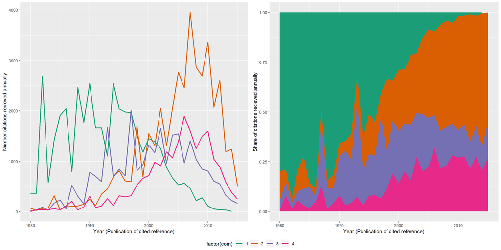

We see number of citations towards the STS knowledge base to sharply increase post-2000. Interestingly, citations to the evolutionary economics and industry-dynamics related knowledge base to completely vanish.

# 3 Research Areas: Bibliographic coupling analysis

This is arguably the most interesting part. Here, we identify the literature’s current knowledge frontier by carrying out a bibliographic coupling analysis of the publications in our corpus. This measure uses bibliographical information of publications to establish a similarity relationship between them. This **coupling-strength} between publications is determined by the number of commonly cited references they share, assuming a common pool of references to indicate similarity in context, methods, or theory. Formally, the strength of the relationship between a publication pair $i$ and $j$ ($s_{i,j}^{bib}$) is expressed by the number of commonly cited references.

$$s_{i,j}^{bib} = \sum_m c_{i,m} c_{j,m}$$

Since our corpus contains publications which differ strongly in terms of the number of cited references, we normalize the coupling strength by the Jaccard similarity coefficient. Here, we weight the intercept of two publications’ bibliography (shared refeences) by their union (number of all references cited by either $i$ or $j$). It is bounded between zero and one, where one indicates the two publications to have an identical bibliography, and zero that they do not share any cited reference. Thereby, we prevent publications from having high coupling strength due to a large bibliography (e.g., literature surveys).

$$S_{i,j}^{jac-bib} =\frac{C(i \cap j)}{C(i \cup j)} = \frac{s_{i,j}^{bib}}{c_i + c_j - s_{i,j}^{bib}}$$

More recent articles have a higher pool of possible references to co-cite to, hence they are more likely to be coupled. Consequently, bibliographic coupling represents a forward looking measure, and the method of choice to identify the current knowledge frontier at the point of analysis.

## 3.1 Identified research areas

To identify communities in the field’s knowledge frontier (labeled **research areas**) we again use the **Lovain Algorithm** (Blondel et al., 2008). We identify the following communities = research areas

| com | n | density_int |
| --- | --- | --- |
| 1 | 2210 | 1.151 |
| 2 | 1765 | 1.368 |
| 3 | 879 | 0.869 |
| 4 | 501 | 1.551 |
| 5 | 423 | 1.638 |
| 6 | 406 | 3.764 |

We on first glance see that RA 1&2 are substantially larger than the rest.

## 3.2 Characterizing the research areas

Now its time to describe them. In the following, I provide some statistics statistics per community which I find helpful to do so:

### 3.2.1 Most central journals, authors, institutions

| Authors AU | Authors dgr.f | Journals JI | Journals dgr | Institutions C | Institutions dgr.f | Keywords DE | Keywords dgr | Most cited References CR | Most cited References n |
| --- | --- | --- | --- | --- | --- | --- | --- | --- | --- |
| **Community 1** |  |  |  |  |  |  |  |  |  |
| Nelson R | 850 | Res Policy | 5032 | University of Sussex | 1371 | innovation | 4417 | Nelson R & Winter S (1982) An Evolutionary Theory of Economic Change | 480 |
| Malerba F | 842 | Ind. Corp. Change | 2317 | Lunds Universitet | 1255 | technological change | 1146 | Dosi G (1982) Research Policy | 248 |
| Leydesdorff L | 679 | Technovation | 1637 | University of Manchester | 1056 | entrepreneurship | 967 | Cohen W & Levinthal D (1990) Administrative Science Quarterly | 175 |
| Dosi G | 626 | Technol. Forecast. Soc. Change | 1347 | Utrecht University | 961 | innovation systems | 938 | Tushman M & Anderson P (1986) Administrative Science Quarterly | 158 |
| Verspagen B | 455 | Technol. Anal. Strateg. Manage. | 930 | Università Bocconi | 915 | innovation policy | 885 | Lundvall B (1992) National Systems of Innovation: Towards a … | 150 |
| Fagerberg J | 406 | J. Evol. Econ. | 831 | Columbia University in the City of New York | 833 | learning | 793 | Porter M (1990) The Competitive Advantage of Nations | 145 |
| Orsenigo L | 380 | Strategic Manage J | 792 | Aalborg Universitet | 718 | networks | 732 | Henderson R & Clark K (1990) Administrative Science Quarterly | 139 |
| Carlsson B | 375 | Eur. Plann. Stud. | 743 | University of Pennsylvania, Wharton School | 691 | technology | 641 | Dosi G (1988) Journal of Economic Literature | 134 |
| Garud R | 344 | Reg. Stud. | 665 | University of Cambridge | 576 | evolution | 557 | Lundvall B (1988) Technical Change and Economic Theory | 125 |
| Lundvall B | 329 | Energy Policy | 663 | Copenhagen Business School | 564 | evolutionary economics | 510 | Pavitt K (1984) Research Policy | 125 |
| **Community 2** |  |  |  |  |  |  |  |  |  |
| Geels F | 1608 | Energy Policy | 2698 | Technische Universiteit Eindhoven | 2582 | sustainability | 2239 | Geels F (2002) Research Policy | 288 |
| Raven R | 1209 | Technol. Forecast. Soc. Change | 2545 | University of Sussex | 2247 | multi-level perspective | 1993 | Rotmans J et al. (2001) Foresight | 251 |
| Smith A | 1014 | Res Policy | 2087 | Erasmus University Rotterdam | 1138 | transition management | 1902 | Geels F & Schot J (2007) Research Policy | 211 |
| Truffer B | 916 | Environmental Innovation and Societal Tran… | 1848 | Utrecht University | 1131 | transitions | 1810 | Unruh G (2000) Energy Policy | 205 |
| Hekkert M | 772 | J. Clean. Prod. | 1638 | Delft University of Technology | 1101 | transition | 1785 | Smith A et al. (2005) Research Policy | 169 |
| Kemp R | 583 | Technol. Anal. Strateg. Manage. | 1486 | Swiss Federal Institute of Aquatic Science… | 1040 | sustainability transitions | 1706 | Rip A & Kemp R (1998) Human Choice and Climate Change | 165 |
| Foxon T | 517 | Global Environ. Change | 612 | Wageningen University and Research Centre | 936 | strategic niche management | 1534 | Kemp R et al. (1998) Technology Analysis and Strategic Management | 154 |
| Markard J | 501 | Energy Res. Soc. Sci. | 582 | University of East Anglia | 878 | innovation | 1506 | Geels F (2004) Research Policy | 148 |
| Kern F | 492 | Sustainability | 519 | Lunds Universitet | 790 | governance | 1052 | Geels F (2002) Res. Policy | 129 |
| Rotmans J | 474 | Futures | 484 | University of Leeds | 744 | socio-technical transitions | 984 | Geels F (2005) Technological Transitions and System Innov… | 106 |
| **Community 3** |  |  |  |  |  |  |  |  |  |
| Folke C | 241 | Ecol. Soc. | 1142 | Stockholms universitet | 591 | resilience | 789 | Folke C et al. (2005) Annual Review of Environment and Resources | 94 |
| Olsson P | 173 | Global Environ. Change | 260 | Arizona State University | 174 | governance | 409 | Walker B et al. (2004) Ecology and Society | 66 |
| Berkes F | 151 | J. Environ. Manage. | 103 | James Cook University, Australia | 173 | adaptive governance | 345 | Olsson P et al. (2006) Ecology and Society | 62 |
| Plummer R | 119 | Environ. Educ. Res. | 96 | University of Manitoba | 166 | social-ecological systems | 345 | Gunderson L & Holling C (2002) Panarchy: Understanding Transformations in… | 61 |
| Fazey I | 103 | Environ. Manage. | 77 | Wageningen University and Research Centre | 137 | adaptive management | 286 | Berkes F et al. (2000) Ecological Applications | 60 |
| Armitage D | 94 | Sustainability | 74 | Commonwealth Scientific and Industrial Res… | 122 | climate change | 281 | Olsson P et al. (2004) Environmental Management | 57 |
| Schultz L | 90 | Local Environ. | 71 | Kungl. Vetenskapsakademien | 121 | adaptive capacity | 253 | Folke C (2006) Global Environmental Change | 55 |
| Gunderson L | 87 | Environ. Sci. Policy | 68 | Brock University | 119 | transformation | 244 | Folke C et al. (2010) Ecology and Society | 52 |
| Reed M | 86 | Environ. Conserv. | 68 | University of Aberdeen | 119 | sustainability | 234 | Berkes F (2009) Journal of Environmental Management | 51 |
| Bulkeley H | 77 | Soc. Nat. Res. | 68 | University of Waterloo | 118 | social learning | 227 | Kates R et al. (2001) Science | 51 |
| **Community 4** |  |  |  |  |  |  |  |  |  |
| Shove E | 129 | J. Consum. Cult. | 161 | RMIT University | 178 | practice theory | 267 | Reckwitz A (2002) European Journal of Social Theory | 85 |
| Strengers Y | 109 | Energy Res. Soc. Sci. | 132 | Lancaster University | 173 | sustainable consumption | 249 | Warde A (2005) Journal of Consumer Culture | 66 |
| Gram-Hanssen K | 96 | J. Clean. Prod. | 88 | University of Manchester | 160 | social practices | 179 | Shove E (2003) Comfort, Cleanliness and Convenience: The … | 48 |
| Halkier B | 78 | Build Res Inf | 79 | Aalborg Universitet | 119 | social practice theory | 164 | Schatzki T (1996) Social Practices: A Wittgensteinian Approa… | 44 |
| Maller C | 77 | Environ. Plann. A | 57 | University of East Anglia | 111 | consumption | 153 | Shove E (2010) Environment and Planning A | 43 |
| Warde A | 70 | Sustainable Practices: Soc. Theory and Cli… | 53 | Roskilde University | 80 | everyday life | 118 | Giddens A (1984) The Constitution of Society | 42 |
| Hargreaves T | 61 | Energy Policy | 52 | Wageningen University and Research Centre | 69 | climate change | 98 | Shove E & Pantzar M (2005) Journal of Consumer Culture | 35 |
| Spaargaren G | 49 | Global Environ. Change | 45 | Keele University | 55 | practices | 94 | Schatzki T (2002) The Site of the Social: A Philosophical Ac… | 32 |
| Martens L | 47 | Geoforum | 44 | University of Exeter | 54 | social practice | 93 | Giddens A (1984) The Constitution of Society: Outline of th… | 27 |
| Keller M | 42 | J. Transp. Geogr. | 33 | Delft University of Technology | 49 | sustainability | 72 | Ajzen I (1991) Organizational Behavior and Human Decision… | 25 |
| **Community 5** |  |  |  |  |  |  |  |  |  |
| Riahi K | 334 | Clim. Change | 339 | International Institute for Applied System… | 498 | climate change | 249 | Moss R et al. (2010) Nature | 58 |
| Kriegler E | 258 | Global Environ. Change | 219 | Potsdam Institut fur Klimafolgenforschung | 429 | scenarios | 121 | Wigley T et al. (1996) Nature | 34 |
| van Vuuren D | 241 | Environ.Res.Lett. | 113 | PBL Netherlands Environmental Assessment A… | 388 | mitigation | 86 | Moss R (2010) Nature | 27 |
| Edmonds J | 191 | Nat. Clim. Change | 75 | Utrecht University | 386 | shared socioeconomic pathways | 83 | O’Neill B et al. (2014) Clim. Change | 26 |
| Calvin K | 187 | Energy Policy | 62 | National Center for Atmospheric Research | 267 | climate policy | 72 | Meinshausen M et al. (2011) Atmos. Chem. Phys. | 24 |
| Fujimori S | 178 | Energy Econ. | 51 | National Institute for Environmental Studi… | 247 | integrated assessment | 69 | Kriegler E et al. (2014) Clim. Change | 22 |
| O’Neill B | 159 | Geoscientific Model Dev. | 44 | Pacific Northwest National Laboratory | 222 | climate change mitigation | 69 | Nordhaus W (1994) Managing the Global Commons: The Economics… | 21 |
| Havlik P | 147 | Technol. Forecast. Soc. Change | 40 | Fondazione Eni Enrico Mattei | 167 | adaptation | 61 | Cline W (1992) The Economics of Global Warming | 18 |
| Krey V | 143 | Environ. Model. Softw. | 36 | Wageningen University and Research Centre | 156 | ssp | 45 | Schneider S & Goulder L (1997) Nature | 18 |
| Ebi K | 142 | Environ. Model. Assess. | 27 | Technische Universitat Graz | 146 | integrated assessment models | 43 | Grubb M (1997) Energy Policy | 16 |
| **Community 6** |  |  |  |  |  |  |  |  |  |
| Durugbo C | 112 | J. Clean. Prod. | 597 | Cranfield University | 279 | product-service systems | 430 | Mont O (2002) Journal of Cleaner Production | 50 |
| Sakao T | 103 | Int J Prod Res | 162 | Linköpings universitet | 152 | sustainability | 304 | Tukker A (2004) Business Strategy and the Environment | 45 |
| Ceschin F | 82 | CIRP J. Manuf. Sci. Technol. | 142 | Shanghai Jiao Tong University | 113 | product-service system | 268 | Aurich J et al. (2006) Journal of Cleaner Production | 35 |
| Ming X | 79 | J. Manuf. Technol. Manage. | 129 | Luleå tekniska Universitet | 107 | servitization | 260 | Tukker A & Tischner U (2006) Journal of Cleaner Production | 34 |
| Wu Z | 79 | Int J Adv Manuf Technol | 106 | Seoul National University | 104 | pss | 201 | Goedkoop M et al. (1999) Product Service Systems, Ecological and Ec… | 33 |
| Tiwari A | 75 | Int. J. Oper. Prod. Manage. | 67 | Aalto University | 94 | product service systems | 161 | Roy R (2000) Futures | 29 |
| Cook M | 72 | Ind. Mark. Manage. | 64 | Università degli Studi di Bergamo | 83 | product-service system (pss) | 121 | Morelli N (2006) Journal of Cleaner Production | 26 |
| Wang L | 70 | Serv. Bus. | 58 | Brunel University London | 69 | product service system | 111 | Alonso-Rasgado T et al. (2004) Journal of Engineering Design | 25 |
| Park Y | 64 | Comput Ind | 56 | Loughborough University | 66 | design | 100 | Manzini E & Vezzoli C (2003) Journal of Cleaner Production | 25 |
| Evans S | 62 | J. Eng. Des. | 55 | Pohang University of Science and Technology | 64 | service | 95 | Oliva R & Kallenberg R (2003) International Journal of Service Industry … | 25 |

Ok, my very condensed interpretation:

- com1: IS, National & sectoral, evolutionary economics, industrial dynamics
- com2: The core of sustainability transitions. Results very similar to the corresponding community in Rakas & Hain (2018)
- com3: Climate change adaption, resilience, governance (not an expert in this literature)
- com4: Sustainable consumption, more behavorial, sociology
- com5: Real enviromental science
- com6: Product-Service systems (interesting concept, honestly never heard of till now)

One small sidenote: There is no real economics community to be found.

### 3.2.2 Most central publications per research area

**Brief reminder:** Centrality in a bibliographic coupling network == representativeness != importance

Therefore, the central articles should be appropriate to characterize the kind of work done in the community, but are not necessarily the most important or influencial ones.

| AU1 | PY | TI | JI | dgr_int |
| --- | --- | --- | --- | --- |
| **Community 1** |  |  |  |  |
| Fagerberg J & Sapprasert K | 2011 | National innovation systems: The emergence of a new approach | Sci. Public Policy | 71.794 |
| Malerba F & Mani S | 2009 | Sectoral systems of innovation and production in developing countries: An introduction | Sectoral Syst. of Innov. and Prod. in Dev. Countries: Actors, Struct. and Evol. | 67.183 |
| Simmie J | 2002 | Knowledge spillovers and reasons for the concentration of innovative SMEs | Urban Stud. | 61.315 |
| Lee J & Park C | 2006 | Research and development linkages in a national innovation system: Factors affecting success and failure in Korea | Technovation | 58.775 |
| Edquist C & Hommen L | 1999 | Systems of innovation: Theory and policy for the demand side | Technol. Soc. | 58.655 |
| Oyelaran-Oyeyinka B | 2005 | Inter-firm collaboration and competitive pressures: SME footwear clusters in Nigeria | Int. J. Technol. Globalisation | 58.523 |
| Midttun A | 2007 | Corporate responsibility from a resource and knowledge perspective Towards a dynamic reinterpretation of C(S)R: Are corporate responsibility and in… | Corp. Gov. | 58.232 |
| Malerba F & Nelson R | 2011 | Learning and catching up in different sectoral systems: Evidence from six industries | Ind. Corp. Change | 57.713 |
| Landstrom H et al. | 2015 | Innovation and entrepreneurship studies: one or two fields of research? | Int. Entrep. Manage. J. | 57.393 |
| Hall J & Kerr R | 2003 | Innovation dynamics and environmental technologies: The emergence of fuel cell technology | J. Clean. Prod. | 57.250 |
| **Community 2** |  |  |  |  |
| Geels F | 2005 | Processes and patterns in transitions and system innovations: Refining the co-evolutionary multi-level perspective | Technol. Forecast. Soc. Change | 71.905 |
| Meelen T & Farla J | 2013 | Towards an integrated framework for analysing sustainable innovation policy | Technol. Anal. Strateg. Manage. | 68.628 |
| Genus A & Coles A | 2008 | Rethinking the multi-level perspective of technological transitions | Res Policy | 67.036 |
| Murphy J & Smith A | 2013 | Understanding transition-periphery dynamics: Renewable energy in the highlands and Islands of Scotland | Environ. Plann. A | 66.812 |
| Fuenfschilling L & Truffer B | 2014 | The structuration of socio-technical regimes - Conceptual foundations from institutional theory | Res Policy | 65.553 |
| Ingram J | 2015 | Framing niche-regime linkage as adaptation: An analysis of learning and innovation networks for sustainable agriculture across Europe | J. Rural Stud. | 65.059 |
| Ingram J et al. | 2015 | Interactions between Niche and Regime: An Analysis of Learning and Innovation Networks for Sustainable Agriculture across Europe | J. Agric. Educ. Ext. | 64.900 |
| Markard J & Truffer B | 2008 | Technological innovation systems and the multi-level perspective: Towards an integrated framework | Res Policy | 64.774 |
| Mazur C et al. | 2015 | Assessing and comparing German and UK transition policies for electric mobility | Environmental Innovation and Societal Transitions | 64.578 |
| Lachman D | 2013 | A survey and review of approaches to study transitions | Energy Policy | 63.913 |
| **Community 3** |  |  |  |  |
| Berkes F | 2017 | Environmental governance for the anthropocene? Social-ecological systems, resilience, and collaborative learning | Sustainability | 24.531 |
| Mitchell M et al. | 2014 | Applying Resilience Thinking to Natural Resource Management through a "“Planning-By-Doing”" Framework | Soc. Nat. Res. | 23.306 |
| Chaffin B et al. | 2014 | A decade of adaptive governance scholarship: Synthesis and future directions | Ecol. Soc. | 21.357 |
| Plummer R | 2013 | Can adaptive comanagement help to address the challenges of climate change adaptation? | Ecol. Soc. | 19.907 |
| Plummer R | 2010 | Social-ecological resilience and environmental education: Synopsis, application, implications | Environ. Educ. Res. | 19.709 |
| Gunderson L et al. | 2006 | Water RATs (resilience, adaptability, and transformability) in lake and wetland social-ecological systems | Ecol. Soc. | 19.401 |
| Hahn T & Nykvist B | 2017 | Are adaptations self-organized, autonomous, and harmonious? Assessing the socialecological resilience literature | Ecol. Soc. | 18.954 |
| Cumming G et al. | 2013 | Resilience, experimentation, and scale mismatches in social-ecological landscapes | Landsc. Ecol. | 18.327 |
| Ros-Tonen M et al. | 2014 | From co-management to landscape governance: Whither Ghana’s modified taungya system? | Forests | 18.162 |
| Schultz L & Lundholm C | 2010 | Learning for resilience? exploring learning opportunities in biosphere reserves | Environ. Educ. Res. | 17.604 |
| **Community 4** |  |  |  |  |
| Gram-Hanssen K | 2011 | Understanding change and continuity in residential energy consumption | J. Consum. Cult. | 21.836 |
| Shove E & Spurling N | 2013 | Sustainable practices: Social theory and climate change | Sustainable Practices: Soc. Theory and Climate Change | 20.738 |
| Maller C | 2015 | Understanding health through social practices: Performance and materiality in everyday life | Sociol. Health Illn. | 20.680 |
| Foulds C et al. | 2013 | Investigating the performance of everyday domestic practices using building monitoring | Build Res Inf | 19.024 |
| Hargreaves T | 2011 | Practice-ing behaviour change: Applying social practice theory to pro-environmental behaviour change | J. Consum. Cult. | 19.000 |
| Mylan J | 2015 | Understanding the diffusion of Sustainable Product-Service Systems: Insights from the sociology of consumption and practice theory | J. Clean. Prod. | 18.989 |
| Welch D & Warde A | 2014 | Theories of practice and sustainable consumption | Handb. of Res. on Sustain. Consum. | 18.840 |
| Galvin R & Sunikka-Blank M | 2016 | Schatzkian practice theory and energy consumption research: Time for some philosophical spring cleaning? | Energy Res. Soc. Sci. | 18.245 |
| Jaeger-Erben M & Offenberger U | 2014 | A practice theory approach to sustainable consumption | GAIA | 18.234 |
| Navari C | 2011 | The concept of practice in the English School | Eur. J. Int. Relat. | 17.926 |
| **Community 5** |  |  |  |  |
| van Vuuren D et al. | 2014 | A new scenario framework for Climate Change Research: Scenario matrix architecture | Clim. Change | 19.448 |
| Kriegler E et al. | 2014 | A new scenario framework for climate change research: The concept of shared climate policy assumptions | Clim. Change | 18.478 |
| Riahi K et al. | 2017 | The Shared Socioeconomic Pathways and their energy, land use, and greenhouse gas emissions implications: An overview | Global Environ. Change | 17.798 |
| van Vuuren D et al. | 2017 | The Shared Socio-economic Pathways: Trajectories for human development and global environmental change | Global Environ. Change | 17.383 |
| Calvin K et al. | 2017 | The SSP4: A world of deepening inequality | Global Environ. Change | 17.099 |
| Ebi K | 2013 | Health in the new scenarios for climate change research | Int. J. Environ. Res. Public Health | 16.905 |
| Schweizer V & O’Neill B | 2014 | Systematic construction of global socioeconomic pathways using internally consistent element combinations | Clim. Change | 16.547 |
| O’Neill B et al. | 2016 | The Scenario Model Intercomparison Project (ScenarioMIP) for CMIP6 | Geoscientific Model Dev. | 16.336 |
| van Vuuren D et al. | 2011 | A special issue on the RCPs | Clim. Change | 15.758 |
| Ebi K et al. | 2014 | A new scenario framework for climate change research: Background, process, and future directions | Clim. Change | 15.680 |
| **Community 6** |  |  |  |  |
| Geum Y & Park Y | 2011 | Designing the sustainable product-service integration: A product-service blueprint approach | J. Clean. Prod. | 29.634 |
| Aurich J et al. | 2009 | Configuration of product-service systems | J. Manuf. Technol. Manage. | 27.351 |
| Sakao T et al. | 2013 | Uncovering benefits and risks of integrated product service offerings - Using a case of technology encapsulation | J. Syst. Sci. Syst. Eng. | 25.728 |
| Long H et al. | 2013 | Product service system configuration based on support vector machine considering customer perception | Int J Prod Res | 25.361 |
| Beuren F et al. | 2013 | Product-service systems: A literature review on integrated products and services | J. Clean. Prod. | 25.258 |
| Medini K & Boucher X | 2016 | Configuration of Product-Service Systems value networks  Evidence from an innovative sector for sludge treatment | CIRP J. Manuf. Sci. Technol. | 25.184 |
| Wang P et al. | 2011 | Status review and research strategies on product-service systems | Int J Prod Res | 24.997 |
| Durugbo C et al. | 2011 | A review of information flow diagrammatic models for product-service systems | Int J Adv Manuf Technol | 24.951 |
| Zhu Q et al. | 2011 | Implementing an industrial product-service system for CNC machine tool | Int J Adv Manuf Technol | 24.903 |
| Park H & Yoon J | 2013 | A chance discovery-based approach for new productservice system (PSS) concepts | Serv. Bus. | 24.756 |

## 3.3 Publications over time

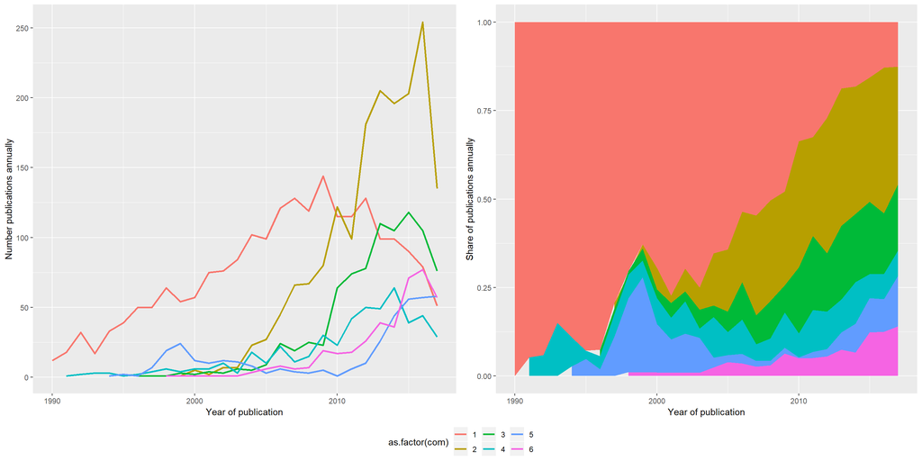

## 3.4 Connectivity between the research areas

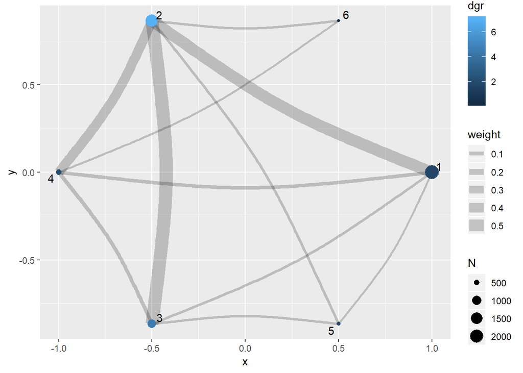

Ok, just to get a first glance, should not be overinterpreted. We see sustainability transition to be the most central community (not surprising, keeping in mind how the corpus is generated). More interestingly, it appears to be strongly connected to IS, climate change adaption and sustainable consumption literature, less so to enviromental science and PSS.

## 3.5 Zooming in the systainability transitions community

In the first scan it can clearly be seen, that the core of the sustainability transitions community resides in **com2**. So, lets zoom in a bit there and look at its internal structure. So, I did a second round of community detection inside **com2** to identify the sub-communities within sustainability transitions. Lets see what we find…

| com | n | density_int |
| --- | --- | --- |
| 1 | 525 | 2.465 |
| 2 | 429 | 3.588 |
| 3 | 409 | 2.561 |
| 4 | 402 | 2.174 |

We here find 4 sub-communities of rather equal size. Lets characterize them…

### 3.5.1 Most central journals, authors, institutions

| Authors AU | Authors dgr.f | Journals JI | Journals dgr | Institutions C | Institutions dgr.f | Keywords DE | Keywords dgr | Most cited References CR | Most cited References n |
| --- | --- | --- | --- | --- | --- | --- | --- | --- | --- |
| **Community 1** |  |  |  |  |  |  |  |  |  |
| Smith A | 228 | Environmental Innovation and Societal Tran… | 514 | University of Sussex | 522 | sustainability transitions | 590 | Geels F & Schot J (2007) Research Policy | 106 |
| Seyfang G | 196 | J. Clean. Prod. | 320 | University of East Anglia | 265 | sustainability | 399 | Geels F (2002) Research Policy | 84 |
| Raven R | 166 | Energy Policy | 316 | Technische Universiteit Eindhoven | 242 | transitions | 391 | Smith A et al. (2005) Research Policy | 69 |
| Geels F | 146 | Res Policy | 288 | Utrecht University | 220 | transition | 376 | Smith A et al. (2010) Research Policy | 59 |
| Longhurst N | 144 | Technol. Forecast. Soc. Change | 195 | University of Manchester | 177 | multi-level perspective | 255 | Geels F (2002) Res. Policy | 57 |
| Kern F | 117 | Technol. Anal. Strateg. Manage. | 180 | University of Leeds | 171 | innovation | 249 | Geels F (2004) Research Policy | 51 |
| Bulkeley H | 108 | Environ. Plann. A | 171 | University of Durham | 155 | governance | 248 | Seyfang G & Smith A (2007) Environmental Politics | 49 |
| Hargreaves T | 90 | Global Environ. Change | 162 | Linköpings universitet | 137 | climate change | 237 | Shove E & Walker G (2007) Environment and Planning A | 48 |
| Rohracher H | 89 | Energy Res. Soc. Sci. | 145 | Wageningen University and Research Centre | 130 | energy | 214 | Geels F & Schot J (2007) Res. Policy | 46 |
| Gibbs D | 84 | Urban Stud. | 133 | UCL | 119 | strategic niche management | 212 | Grin J et al. (2010) Transitions to Sustainable Devel… | 43 |
| **Community 2** |  |  |  |  |  |  |  |  |  |
| Geels F | 793 | Res Policy | 419 | Technische Universiteit Eindhoven | 1076 | multi-level perspective | 567 | Geels F (2002) Research Policy | 103 |
| Raven R | 386 | Energy Policy | 399 | University of Sussex | 316 | strategic niche management | 441 | Kemp R et al. (1998) Technology Analysis and Strategi… | 84 |
| Smith A | 185 | Technol. Anal. Strateg. Manage. | 362 | University of Twente | 228 | transition | 262 | Rip A & Kemp R (1998) Human Choice and Climate Change | 79 |
| Schot J | 182 | Technol. Forecast. Soc. Change | 319 | Wageningen University and Research Centre | 203 | sustainability | 253 | Hoogma R et al. (2002) Experimenting for Sustainable Tr… | 60 |
| Kemp R | 181 | Technol. Soc. | 185 | University of Amsterdam | 134 | system innovation | 234 | Schot J et al. (1994) Futures | 58 |
| Verbong G | 152 | J. Clean. Prod. | 151 | Vrije Universiteit Amsterdam | 128 | co-evolution | 231 | Geels F (2004) Research Policy | 46 |
| Truffer B | 137 | Environmental Innovation and Societal Tran… | 131 | University of Cambridge | 114 | transition management | 194 | Kemp R (1994) Futures | 45 |
| Berkhout F | 104 | Syst. Innov. and the Transit. to Sustainab… | 122 | Swiss Federal Institute of Aquatic Science… | 106 | innovation | 188 | Nelson R & Winter S (1982) An Evolutionary Theory of Econom… | 41 |
| Elzen B | 89 | Sci. Technol. Hum. Values | 109 | Erasmus University Rotterdam | 105 | transitions | 139 | Unruh G (2000) Energy Policy | 41 |
| Lovell H | 81 | Technovation | 79 | Imperial College London | 103 | biomass | 129 | Geels F & Schot J (2007) Research Policy | 39 |
| **Community 3** |  |  |  |  |  |  |  |  |  |
| Rotmans J | 198 | Technol. Forecast. Soc. Change | 217 | Erasmus University Rotterdam | 318 | transition management | 452 | Rotmans J et al. (2001) Foresight | 179 |
| Brown R | 165 | J. Clean. Prod. | 184 | Delft University of Technology | 243 | transitions | 283 | Geels F (2002) Research Policy | 45 |
| Loorbach D | 150 | Environmental Innovation and Societal Tran… | 112 | Monash University | 193 | sustainability | 244 | Geels F & Schot J (2007) Research Policy | 42 |
| Kemp R | 122 | Futures | 103 | Wageningen University and Research Centre | 116 | governance | 186 | Smith A et al. (2005) Research Policy | 39 |
| Whitmarsh L | 95 | Energy Policy | 90 | University of Sussex | 101 | sustainable development | 160 | Rip A & Kemp R (1998) Human Choice and Climate Change | 35 |
| Farrelly M | 88 | Sustainability | 85 | University of East Anglia | 72 | transition | 157 | Loorbach D (2010) Governance | 30 |
| Bergman N | 85 | Policy Sci. | 76 | Tellus Institute | 69 | innovation | 149 | Loorbach D (2007) Transition Management: New Mode … | 29 |
| Schilperoord M | 74 | Ecol. Soc. | 70 | UNU-MERIT | 68 | socio-technical transitions | 97 | Geels F (2005) Technological Transitions and Sy… | 28 |
| Meadowcroft J | 63 | Res Policy | 64 | University of Oxford | 67 | sustainability transitions | 85 | Loorbach D & Rotmans J (2006) Understanding Industrial Transfo… | 24 |
| Smith A | 60 | Global Environ. Change | 61 | Carleton University | 63 | urban water | 81 | Shove E & Walker G (2007) Environment and Planning A | 24 |
| **Community 4** |  |  |  |  |  |  |  |  |  |
| Hekkert M | 338 | Energy Policy | 489 | Swiss Federal Institute of Aquatic Science… | 289 | technological innovation systems | 270 | Unruh G (2000) Energy Policy | 106 |
| Truffer B | 226 | Technol. Forecast. Soc. Change | 424 | Copernicus Institute for Sustainable Devel… | 265 | technological innovation system | 266 | Jacobsson S & Johnson A (2000) Energy Policy | 86 |
| Jacobsson S | 198 | Res Policy | 219 | Utrecht University | 255 | innovation | 154 | Jacobsson S & Lauber V (2006) Energy Policy | 69 |
| Markard J | 165 | Technol. Anal. Strateg. Manage. | 179 | Chalmers University of Technology | 231 | sustainability | 152 | Jacobsson S & Bergek A (2004) Industrial and Corporate Change | 67 |
| Suurs R | 124 | Environmental Innovation and Societal Tran… | 175 | Lunds Universitet | 179 | innovation system | 146 | Geels F (2002) Research Policy | 56 |
| Coenen L | 123 | J. Clean. Prod. | 104 | Linköpings universitet | 136 | innovation policy | 144 | Bergek A et al. (2008) Research Policy | 53 |
| Bergek A | 114 | Eur. Plann. Stud. | 88 | University of Sussex | 119 | renewable energy | 137 | Hekkert M et al. (2007) Technological Forecasting and So… | 48 |
| Negro S | 105 | Energy Res. Soc. Sci. | 54 | Studier av innovasjon, forskning og utdanning | 103 | innovation systems | 126 | Markard J & Truffer B (2008) Research Policy | 44 |
| Foxon T | 85 | Sustainability | 33 | Technische Universiteit Eindhoven | 99 | policy | 108 | Carlsson B & Stankiewicz R (1991) Journal of Evolutionary Economics | 42 |
| Hillman K | 75 | Energy | 30 | University of Leeds | 94 | biofuels | 92 | Bergek A et al. (2008) Res. Policy | 39 |

For me it seems as if there are differences, but I guess one has to look closer. Is that helpful?

### 3.5.2 Most central publications per research area

| AU1 | PY | TI | JI | dgr_int |
| --- | --- | --- | --- | --- |
| **Community 1** |  |  |  |  |
| Ingram J | 2015 | Framing niche-regime linkage as adaptation: An analysis of learning and innovation networks for sustainable agriculture across Europe | J. Rural Stud. | 31.794 |
| Hargreaves T et al. | 2013 | Up, down, round and round: Connecting regimes and practices in innovation for sustainability | Environ. Plann. A | 31.126 |
| Fuenfschilling L & Truffer B | 2014 | The structuration of socio-technical regimes - Conceptual foundations from institutional theory | Res Policy | 29.075 |
| Ingram J et al. | 2015 | Interactions between Niche and Regime: An Analysis of Learning and Innovation Networks for Sustainable Agriculture across Europe | J. Agric. Educ. Ext. | 28.234 |
| Lachman D | 2013 | A survey and review of approaches to study transitions | Energy Policy | 28.166 |
| Raven R et al. | 2016 | The politics of innovation spaces for low-carbon energy: Introduction to the special issue | Environmental Innovation and Societal Tran… | 27.789 |
| Mattes J et al. | 2015 | Energy transitions in small-scale regions - What we can learn from a regional innovation systems perspective | Energy Policy | 26.850 |
| Seyfang G et al. | 2010 | Energy and communities in transition - Towards a new research agenda on agency and civil society in sustainability transitions | Work. Pap. Cent. Soc. Econ. Res. Global En… | 26.652 |
| Pesch U | 2015 | Tracing discursive space: Agency and change in sustainability transitions | Technol. Forecast. Soc. Change | 26.338 |
| Ravena R et al. | 2012 | Space and scale in socio-Technical transitions | Environmental Innovation and Societal Tran… | 26.280 |
| **Community 2** |  |  |  |  |
| Geels F | 2004 | Understanding system innovations: A critical literature review and a conceptual synthesis | Syst. Innov. and the Transit. to Sustainab… | 46.710 |
| Geels F | 2005 | Processes and patterns in transitions and system innovations: Refining the co-evolutionary multi-level perspective | Technol. Forecast. Soc. Change | 40.023 |
| Raven R | 2006 | Towards alternative trajectories? Reconfigurations in the Dutch electricity regime | Res Policy | 39.380 |
| Raven R | 2007 | Co-evolution of waste and electricity regimes: Multi-regime dynamics in the Netherlands (1969-2003) | Energy Policy | 38.071 |
| Geels F & Schot J | 2007 | Typology of sociotechnical transition pathways | Res Policy | 37.118 |
| Geels F | 2006 | Major system change through stepwise reconfiguration: A multi-level analysis of the transformation of American factory production (1850-1930) | Technol. Soc. | 37.012 |
| Geels F & Kemp R | 2006 | Transitions, Transformations, and Reproduction: Dynamics in Socio-Technical Systems | Flex. and Stab. in the Innov. Econ. | 36.264 |
| Simmie J et al. | 2014 | New technological path creation: evidence from the British and German wind energy industries | J. Evol. Econ. | 36.065 |
| Geels F | 2007 | Analysing the breakthrough of rock ‘n’ roll (1930-1970) Multi-regime interaction and reconfiguration in the multi-level perspective | Technol. Forecast. Soc. Change | 34.661 |
| Geels F & Kemp R | 2007 | Dynamics in socio-technical systems: Typology of change processes and contrasting case studies | Technol. Soc. | 34.260 |
| **Community 3** |  |  |  |  |
| Brunori G et al. | 2012 | On the New Social Relations around and beyond Food. Analysing Consumers’ Role and Action in Gruppi di Acquisto Solidale (Solidarity Purchasing Groups) | Sociol. Ruralis | 22.662 |
| Schilperoord M et al. | 2008 | Modelling societal transitions with agent transformation | Comput. Math. Organ. Theory | 22.120 |
| Pekkarinen S et al. | 2011 | Clashes as potential for innovation in public service sector reform | Int. J. Public Sect. Manage. | 22.013 |
| van Staveren M et al. | 2014 | Lets bring in the floods: de-poldering in the Netherlands as a strategy for long-term delta survival? | Water Int. | 19.629 |
| Kemp R | 2010 | The Dutch energy transition approach | Int. Econ. Econ. Policy | 19.256 |
| De Haan F et al. | 2014 | The needs of society: A new understanding of transitions, sustainability and liveability | Technol. Forecast. Soc. Change | 19.029 |
| Smith A & Stirling A | 2010 | The politics of social-ecological resilience and sustainable socio-technical transitions | Ecol. Soc. | 18.736 |
| Bergman N et al. | 2008 | Modelling socio-technical transition patterns and pathways | JASSS | 18.733 |
| Ortiz W et al. | 2012 | Introducing modern energy services into developing countries: The role of local community socio-economic structures | Sustainability | 18.456 |
| Kemp R et al. | 2011 | Transition management as a model for sustainable mobility | Eur. Transp. Trasporti Eur. | 18.416 |
| **Community 4** |  |  |  |  |
| Lovio R & Kivimaa P | 2012 | Comparing Alternative Path Creation Frameworks in the Context of Emerging Biofuel Fields in the Netherlands, Sweden and Finland | Eur. Plann. Stud. | 21.184 |
| Edsand H | 2017 | Identifying barriers to wind energy diffusion in Colombia: A function analysis of the technological innovation system and the wider context | Technol. Soc. | 21.181 |
| Vidican G et al. | 2012 | An empirical examination of the development of a solar innovation system in the United Arab Emirates | Energy Sustainable Dev. | 20.665 |
| van Alphen K et al. | 2009 | The performance of the Norwegian carbon dioxide, capture and storage innovation system | Energy Policy | 20.251 |
| Hellsmark H & Jacobsson S | 2009 | Opportunities for and limits to Academics as System builders-The case of realizing the potential of gasified biomass in Austria | Energy Policy | 20.235 |
| Jacobsson S & Bergek A | 2011 | Innovation system analyses and sustainability transitions: Contributions and suggestions for research | Environmental Innovation and Societal Tran… | 20.005 |
| Markard J & Truffer B | 2008 | Technological innovation systems and the multi-level perspective: Towards an integrated framework | Res Policy | 19.991 |
| Meelen T & Farla J | 2013 | Towards an integrated framework for analysing sustainable innovation policy | Technol. Anal. Strateg. Manage. | 19.395 |
| Hillman K et al. | 2008 | Cumulative causation in biofuels development: A critical comparison of the Netherlands and Sweden | Technol. Anal. Strateg. Manage. | 18.928 |
| Dewald U & Truffer B | 2011 | Market formation in technological innovation systems-diffusion of photovoltaic applications in Germany | Ind. Innov. | 18.450 |

I know to little about the internal dynamics in the field, but hope that makes somewhat sense…

### 3.5.3 Internal network

Finally, we can take a look at the most central publications (tob 50) in the community via a network plot.

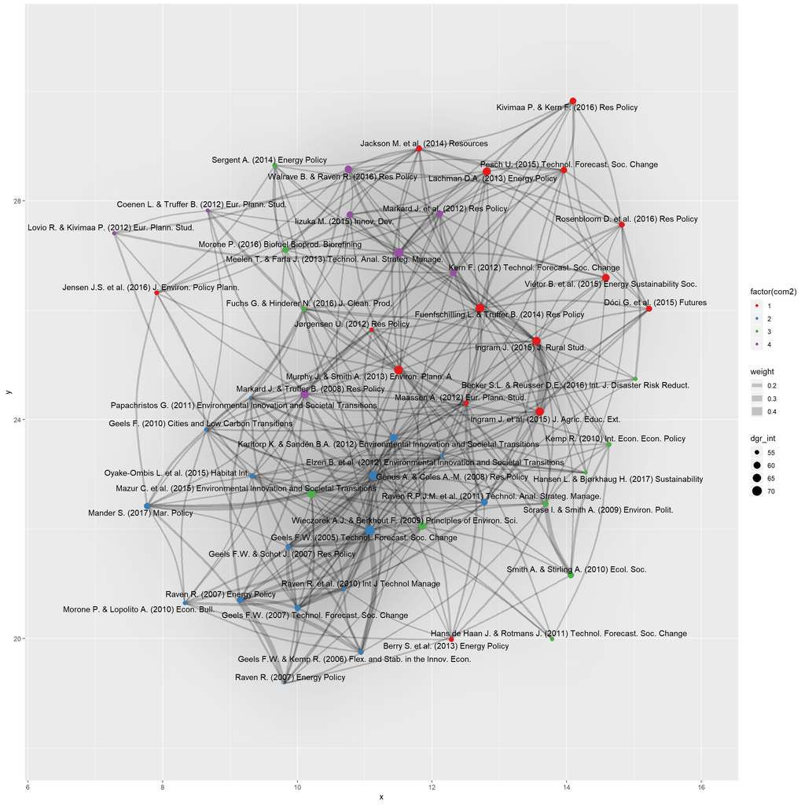

# 4 Topic modelling

still to-do

# 5 2-Mode dynamics

still to-do